# Exercício: SARIMA no comércio varejista brasileiro

Trabalho de aprendizado da disciplina Financial Analytics · Programa Avançado de Data Science e Decisão (Insper)

Autor

Beatriz Laurino

Data de Publicação

28/10/2026

## Sobre o exercício

A base é a **PMC** (Pesquisa Mensal do Comércio) do IBGE: índice de volume de vendas no **comércio varejista ampliado** (inclui veículos e materiais de construção), por **Unidade da Federação**, mensal de jan/2004 em diante. Base 2022 = 100, **sem ajuste sazonal**.

## Setup

```python
import numpy as np
import pandas as pd
import matplotlib.pyplot as plt
import plotly.express as px
import plotly.graph_objects as go
from plotly.subplots import make_subplots


from statsmodels.tsa.stattools import adfuller, kpss
from statsmodels.graphics.tsaplots import plot_acf, plot_pacf
from statsmodels.tsa.seasonal import STL

from statsforecast import StatsForecast
from statsforecast.models import AutoARIMA, ARIMA
from statsforecast.arima import ndiffs, nsdiffs
from statsmodels.stats.diagnostic import acorr_ljungbox
```

## Carregando a base PMC

A base já foi pré-processada para conter apenas as colunas relevantes, e já no formato “long” (uma linha por data + UF). O nome da coluna de data é “data”, e a coluna de interesse (índice de volume) é “volume_idx”. A coluna “uf” indica a Unidade da Federação.

```python
pmc = pd.read_csv("https://github.com/padsInsper/202634-fa/releases/download/data/pmc_volume_uf.csv")
```

## Escolha sua UF

```python
MINHA_UF = "Ceará"


df_sf = (
    pmc.query("uf == @MINHA_UF")
    .rename(columns={"uf": "unique_id", "data": "ds", "volume_idx": "y"})
    [["unique_id", "ds", "y"]]
    .reset_index(drop=True)
)

df_sf["ds"] = pd.to_datetime(df_sf["ds"])

serie = df_sf.set_index("ds")["y"].asfreq("MS")

df_sf.head()
```

|  | unique_id | ds | y |
| --- | --- | --- | --- |
| 0 | Ceará | 2004-01-01 | 38.39606 |
| 1 | Ceará | 2004-02-01 | 34.60505 |
| 2 | Ceará | 2004-03-01 | 38.88208 |
| 3 | Ceará | 2004-04-01 | 37.91003 |
| 4 | Ceará | 2004-05-01 | 40.14575 |

## Análise descritiva

### Validação Visual Inicial

Por uma validação inicial dos dados, podemos já identificar alguns pontos: - Pico nos meses de Dezembro - Vale nos meses de Fevereiro - Crescimento (apesar de inconstante) desde 2005 - Visualmente a variância parece constante

```python
fig = px.line(
    df_sf, x='ds', y='y',
    title=f'Volume Mensal do Varejo: {MINHA_UF}',
    labels={'ds': 'Data', 'y': 'Volume'},
    template='plotly_white'
)
fig.update_layout(
    font_family="Inter",
    title_font_size=18,
    hovermode='x unified'
)
fig.show()
```

[interactive chart not shown]

### Decomposição

A decomposição deixa bem evidente tanto a tendência quanto a sazonalidade

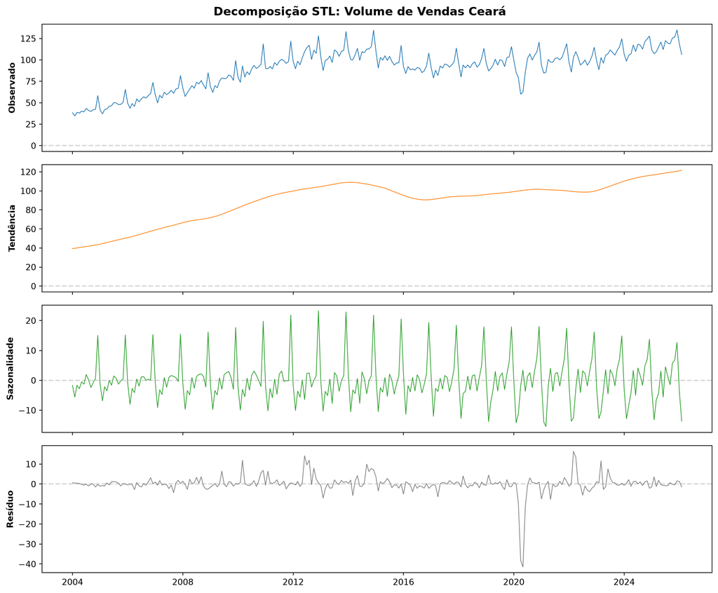

```python
# Decomposição STL
stl = STL(serie, period=12, robust=True)
resultado = stl.fit()

fig, axes = plt.subplots(4, 1, figsize=(12, 10), sharex=True)

componentes = {
    'Observado': serie,
    'Tendência': resultado.trend,
    'Sazonalidade': resultado.seasonal,
    'Resíduo': resultado.resid
}
cores = ['tab:blue', 'tab:orange', 'tab:green', 'gray']

for ax, (nome, comp), cor in zip(axes, componentes.items(), cores):
    ax.plot(comp, color=cor, linewidth=0.8)
    ax.set_ylabel(nome, fontweight='bold')
    ax.axhline(y=0, color='gray', linestyle='--', alpha=0.3)

plt.suptitle(f'Decomposição STL: Volume de Vendas {MINHA_UF}', fontsize=14, fontweight='bold')
plt.tight_layout()
plt.show()
```

### ACF PACF

Avaliando ACF e PACF, vemos um decréscimo lento na autocorrelação e um pico concentrado no M1 da parcial, o que indica não estacionariedade, e a série provavelmente precisa de uma diferenciação.

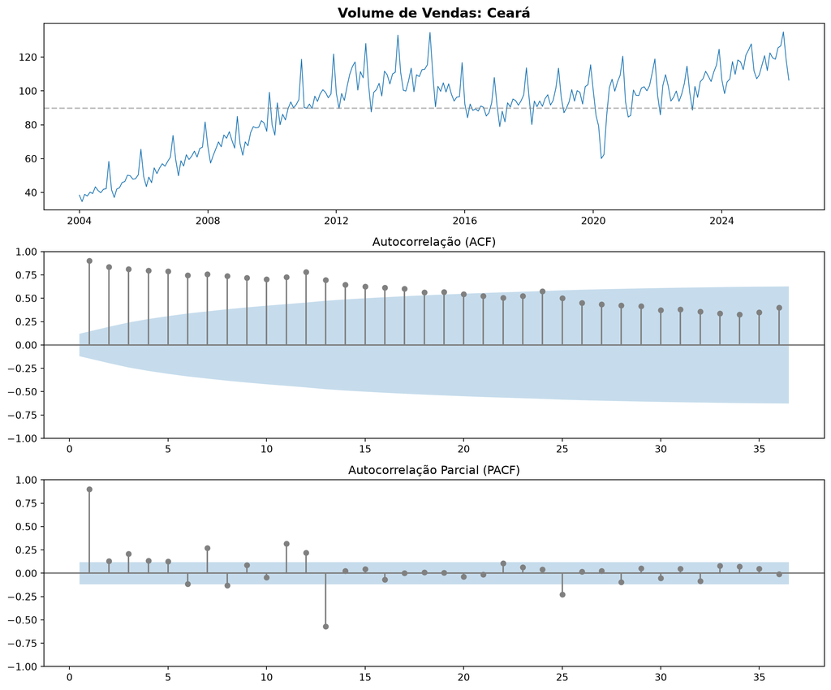

```python
def plotar_diagnostico(serie, titulo="Série", lags=36):
    """Plota série + ACF + PACF em layout 3x1"""
    fig, axes = plt.subplots(3, 1, figsize=(12, 10))

    # Série
    axes[0].plot(serie, color='tab:blue', linewidth=0.8)
    axes[0].set_title(f'{titulo}', fontweight='bold', fontsize=14)
    axes[0].axhline(y=serie.mean(), color='gray', linestyle='--', alpha=0.5)

    # ACF
    plot_acf(serie.dropna(), ax=axes[1], lags=lags, zero=False,
             color='gray', vlines_kwargs={'colors': 'gray'})
    axes[1].set_title('Autocorrelação (ACF)')

    # PACF
    plot_pacf(serie.dropna(), ax=axes[2], lags=lags, zero=False,
              color='gray', vlines_kwargs={'colors': 'gray'})
    axes[2].set_title('Autocorrelação Parcial (PACF)')

    plt.tight_layout()
    plt.show()

plotar_diagnostico(serie, f'Volume de Vendas: {MINHA_UF}')
```

### Testes de Estacionariedade

Quando testamos a estacionariedade, confirmamos a hipótese de que a série é não estacionária

```python
def testar_estacionariedade(serie, nome="Série"):
    """Aplica testes ADF e KPSS e interpreta resultados"""
    print(f"{'='*50}")
    print(f"Testes de Estacionariedade: {nome}")
    print(f"{'='*50}\n")

    # ADF
    resultado_adf = adfuller(serie.dropna(), autolag='AIC')
    print(f"Teste ADF (H0: raiz unitária)")
    print(f"  Estatística: {resultado_adf[0]:.4f}")
    print(f"  p-valor:     {resultado_adf[1]:.4f}")
    print(f"  Lags usados: {resultado_adf[2]}")

    if resultado_adf[1] < 0.05:
        print(f"  → Rejeita H0: evidência de estacionariedade\n")
    else:
        print(f"  → Não rejeita H0: evidência de raiz unitária\n")

    # KPSS
    resultado_kpss = kpss(serie.dropna(), regression='c', nlags='auto')
    print(f"Teste KPSS (H0: estacionária)")
    print(f"  Estatística: {resultado_kpss[0]:.4f}")
    print(f"  p-valor:     {resultado_kpss[1]:.4f}")

    if resultado_kpss[1] < 0.05:
        print(f"  → Rejeita H0: evidência de não-estacionariedade\n")
    else:
        print(f"  → Não rejeita H0: evidência de estacionariedade\n")

    # Conclusão conjunta
    adf_estacionaria = resultado_adf[1] < 0.05
    kpss_estacionaria = resultado_kpss[1] >= 0.05

    if adf_estacionaria and kpss_estacionaria:
        print("CONCLUSÃO: Série provavelmente ESTACIONÁRIA")
    elif not adf_estacionaria and not kpss_estacionaria:
        print("CONCLUSÃO: Série provavelmente NÃO ESTACIONÁRIA")
    else:
        print("CONCLUSÃO: Resultados INCONCLUSIVOS: análise adicional necessária")

testar_estacionariedade(serie, f'Volume de Vendas: {MINHA_UF}')
```

```
==================================================
Testes de Estacionariedade: Volume de Vendas: Ceará
==================================================

Teste ADF (H0: raiz unitária)
  Estatística: -2.1074
  p-valor:     0.2416
  Lags usados: 12
  → Não rejeita H0: evidência de raiz unitária

Teste KPSS (H0: estacionária)
  Estatística: 1.7208
  p-valor:     0.0100
  → Rejeita H0: evidência de não-estacionariedade

CONCLUSÃO: Série provavelmente NÃO ESTACIONÁRIA
```

### Diferenciação

Após aplicação da primeira diferença, observamos ambas hipóteses (ADF e KPSS) rejeitando H0, o que pode indicar tendência determinística.

Após a primeira diferença, apesar de não observar mais a tendência, ainda vemos claramente os picos sazonais. Vemos no ACF repetições anuais (picos acentuados a cada 12 meses). Por este motivo, cabe adicionarmos uma segunda diferenciação, para remover a sazonalidade.

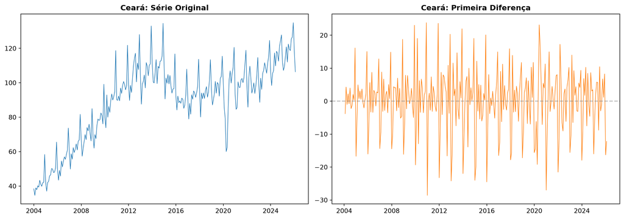

```
==================================================
Testes de Estacionariedade: Ceará (1ª diferença)
==================================================

Teste ADF (H0: raiz unitária)
  Estatística: -5.7514
  p-valor:     0.0000
  Lags usados: 11
  → Rejeita H0: evidência de estacionariedade

Teste KPSS (H0: estacionária)
  Estatística: 0.5000
  p-valor:     0.0417
  → Rejeita H0: evidência de não-estacionariedade

CONCLUSÃO: Resultados INCONCLUSIVOS: análise adicional necessária
```

```python
# Primeira diferença
serie_diff = serie.diff().dropna()

fig, axes = plt.subplots(1, 2, figsize=(14, 5))

axes[0].plot(serie, color='tab:blue', linewidth=0.8)
axes[0].set_title(f'{MINHA_UF}: Série Original', fontweight='bold')

axes[1].plot(serie_diff, color='tab:orange', linewidth=0.8)
axes[1].set_title(f'{MINHA_UF}: Primeira Diferença', fontweight='bold')
axes[1].axhline(y=0, color='gray', linestyle='--', alpha=0.5)

plt.tight_layout()
plt.show()

# Testes na série diferenciada
testar_estacionariedade(serie_diff, f'{MINHA_UF} (1ª diferença)')
```

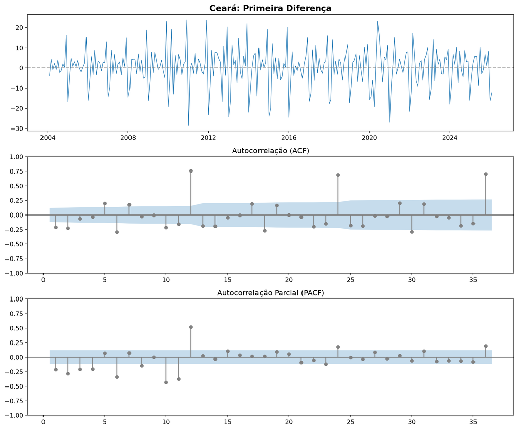

```python
# Diagnóstico da série diferenciada
plotar_diagnostico(serie_diff, f'{MINHA_UF}: Primeira Diferença')
```

Com a segunda diferença removemos a sazonalidade e podemos observar uma série estacionária.

```
==================================================
Testes de Estacionariedade: Ceará (1ª diferença)
==================================================

Teste ADF (H0: raiz unitária)
  Estatística: -6.2885
  p-valor:     0.0000
  Lags usados: 11
  → Rejeita H0: evidência de estacionariedade

Teste KPSS (H0: estacionária)
  Estatística: 0.0873
  p-valor:     0.1000
  → Não rejeita H0: evidência de estacionariedade

CONCLUSÃO: Série provavelmente ESTACIONÁRIA
```

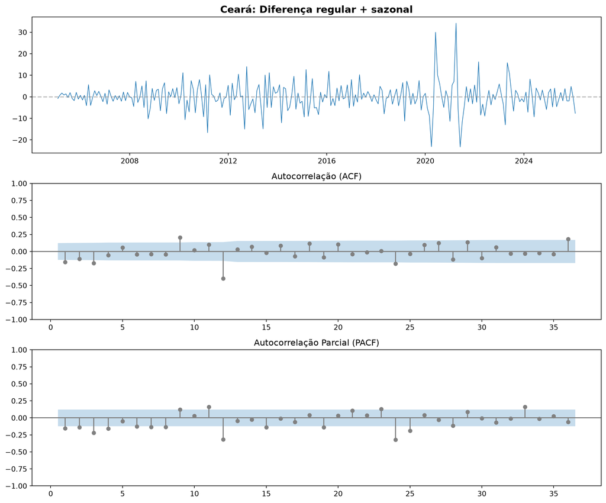

```python
# Segunda diferença
serie_diff_sazonal = serie.diff().diff(12).dropna()

testar_estacionariedade(serie_diff_sazonal, f'{MINHA_UF} (1ª diferença)')

plotar_diagnostico(serie_diff_sazonal, f'{MINHA_UF}: Diferença regular + sazonal')
```

Rodando ndiffs, confirmamos 1 sazonal e 1 regular

```python
y = serie.values
print("nsdiffs (sazonal):", nsdiffs(y, period=12))
print("ndiffs (regular, após diferença sazonal):", ndiffs(y[12:] - y[:-12]))
```

```
nsdiffs (sazonal): 1
ndiffs (regular, após diferença sazonal): 1
```

## Modelagem

### Ajuste do SARIMA via AutoARIMA

```python
# AutoARIMA testa várias ordens (p,d,q)(P,D,Q) e escolhe a de menor AICc.
# season_length=12 → considera a parte sazonal (série mensal)
sf = StatsForecast(models=[AutoARIMA(season_length=12)], freq='MS', n_jobs=1)
sf.fit(df_sf)

modelo = sf.fitted_[0, 0].model_

# Atenção: a ordem em 'arma' é (p, q, P, Q, s, d, D)
p, q, P, Q, s, d, D = modelo['arma']
print(f"Modelo escolhido: SARIMA({p},{d},{q})({P},{D},{Q})[{s}]")
print(f"AICc: {modelo['aicc']:.2f}")
```

```
Modelo escolhido: SARIMA(0,1,3)(1,1,2)[12]
AICc: 1534.11
```

```python
# Coeficientes estimados (ar = AR, ma = MA, sar/sma = partes sazonais)
pd.Series(modelo['coef'])
```

```
ma1    -0.307656
ma2    -0.158158
ma3    -0.157866
sar1   -0.559998
sma1   -0.139544
sma2   -0.647357
dtype: float64
```

```python
sf2 = StatsForecast(models=[ARIMA(order=(0,1,1), seasonal_order=(0,1,1), season_length=12)], freq='MS')
sf2.fit(df_sf)

modelo2_teste = sf2.fitted_[0, 0].model_

print(modelo2_teste['aicc'])
```

```
1552.4304491255489
```

### Diagnóstico dos resíduos

Resíduos da série bem baixos, sempre por volta de zero, indicando bom ajuste da previsão do Auto ARIMA

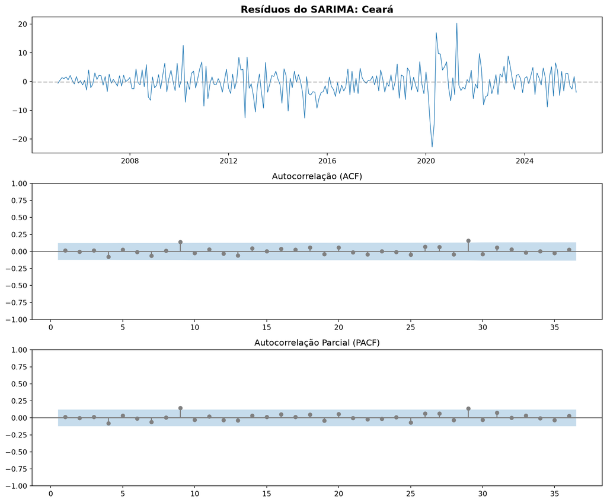

```python
residuos = pd.Series(modelo['residuals'], index=serie.index)
residuos = residuos.iloc[d + s * D:]

plotar_diagnostico(residuos, f'Resíduos do SARIMA: {MINHA_UF}')
```

Se simulo a versão manual que testei, vemos que ainda assim os resíduos são baixos, apesar de maiores do que o automático.

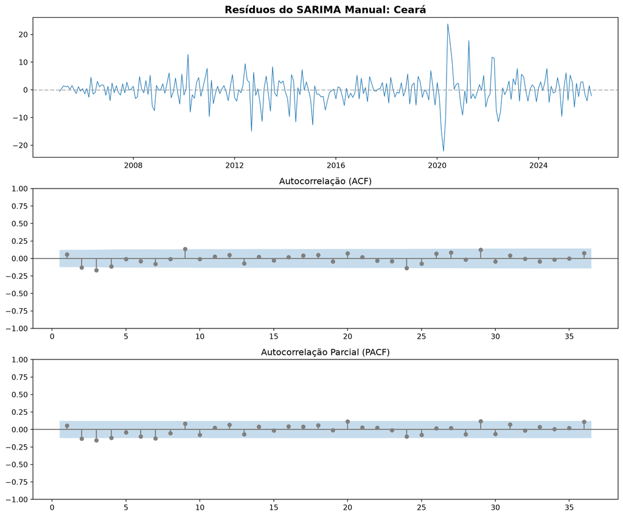

```python
residuos2 = pd.Series(modelo2_teste['residuals'], index=serie.index)
residuos2 = residuos2.iloc[d + s * D:]

plotar_diagnostico(residuos2, f'Resíduos do SARIMA Manual: {MINHA_UF}')
```

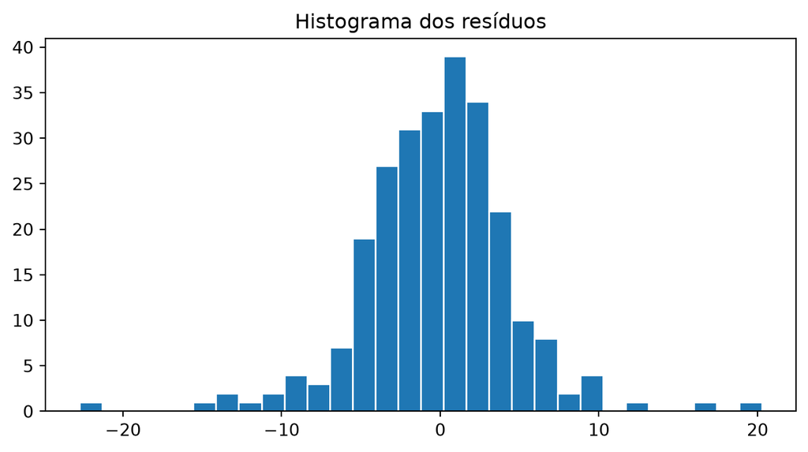

```python
fig, ax = plt.subplots(figsize=(8, 4))
ax.hist(residuos, bins=30, color='tab:blue', edgecolor='white')
ax.set_title('Histograma dos resíduos')
plt.show()
```

```python
# Teste de Ljung-Box (H0: resíduos são ruído branco, sem autocorrelação)

acorr_ljungbox(residuos, lags=[6, 12, 24], model_df=p + q + P + Q)
```

|  | lb_stat | lb_pvalue |
| --- | --- | --- |
| 6 | 1.956381 | NaN |
| 12 | 8.904675 | 0.17901 |
| 24 | 13.864973 | 0.73785 |

## Previsão

```python
previsao = sf.predict(h=24, level=[80, 95])
previsao.head()
```

|  | unique_id | ds | AutoARIMA | AutoARIMA-lo-95 | AutoARIMA-lo-80 | AutoARIMA-hi-80 | AutoARIMA-hi-95 |
| --- | --- | --- | --- | --- | --- | --- | --- |
| 0 | Ceará | 2026-03-01 | 113.728269 | 104.368561 | 107.608285 | 119.848253 | 123.087977 |
| 1 | Ceará | 2026-04-01 | 115.422481 | 104.038379 | 107.978817 | 122.866146 | 126.806584 |
| 2 | Ceará | 2026-05-01 | 121.366981 | 108.933298 | 113.237032 | 129.496929 | 133.800663 |
| 3 | Ceará | 2026-06-01 | 118.173399 | 105.250456 | 109.723541 | 126.623258 | 131.096342 |
| 4 | Ceará | 2026-07-01 | 124.911408 | 111.517065 | 116.153318 | 133.669499 | 138.305752 |

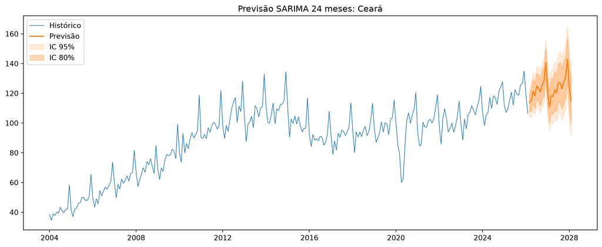

```python
fig, ax = plt.subplots(figsize=(12, 5))

ax.plot(df_sf['ds'], df_sf['y'], color='tab:blue', linewidth=0.8, label='Histórico')

ax.plot(previsao['ds'], previsao['AutoARIMA'], color='tab:orange', linewidth=1.5, label='Previsão')

# Intervalos de 95% e 80%
ax.fill_between(previsao['ds'], previsao['AutoARIMA-lo-95'], previsao['AutoARIMA-hi-95'],
                color='tab:orange', alpha=0.15, label='IC 95%')
ax.fill_between(previsao['ds'], previsao['AutoARIMA-lo-80'], previsao['AutoARIMA-hi-80'],
                color='tab:orange', alpha=0.30, label='IC 80%')

ax.set_title(f'Previsão SARIMA 24 meses: {MINHA_UF}')
ax.legend(loc='upper left')
plt.tight_layout()
plt.show()
```

## Discussão

### O ACF/PACF da série original sugeriu sazonalidade? E tendência? Bate com o que você viu no gráfico de linha?

Sim, tanto ACF/PACF quanto o gráfico de linha inicial sugeriram ambas, e foi possível confirmar conforme fiz as diferenciações.

### Quantas diferenças (regular e sazonal) o AutoARIMA aplicou? E os componentes AR/MA? Conseguiu observar isso no ACF/PACF?

Duas diferenças: uma regular e uma sazonal, o que está alinhado com o que eu analisei no ACF PACF. Quanto a AR/MA, após as duas diferenças o ACF PACF me indicava majoritariamente ruído já, com os lags pequenos em torno de zero. A única coisa que ainda chamava atenção eram os lags de múltiplos de 12, o que talvez indicasse um MA sazonal, mas o autoARIMA escolheu q = 3 e P = 1 o que de fato diminui 18 pontos no AICc comparado com um modelo (0,1,1)(0,1,1), que era o que eu esperava só avaliando ACF PACF.

### Os resíduos parecem white noise? Algum padrão remanescente sazonal?

Sim, os resíduos parecem white noise e não resta um claro padrão sazonal.

### A previsão pareceu razoável visualmente (captura a sazonalidade, fica bem ancorada no histórico, intervalos abrem muito com o horizonte)?

A previsão parece muito bem ajustada e capturando a tendência + sazonalidade observada no passado.

### Que outras UFs você imagina que dariam um SARIMA bem diferente do seu (e por quê)? Pense em estados de regiões diferentes, com perfil econômico distinto.

A princípio não esperaria que o volume mensal do Varejo mudasse tanto o comportamento ao longo do tempo em outras regiões do Brasil. Eu esperaria que a sazonalidade por exemplo fosse bem consistente em todo o país (volume maior em Dezembro, associado provavelmente a festas de fim de ano/13o salário, seguido por um decréscimo nos primeiros meses do ano).

Apesar disso, pensando em atividade econômica, estados que possuem forte atividade agrícola por exemplo, como Mato Grosso, Goiás, podem mexer na dinâmica de sazonalidade além do mês de dezembro, dado que a renda é bastante atrelada a momentos de colheita. Isso poderia levar a ordens diferentes no SARIMA.

Além disso, pode ser mais provável observarmos mais outros choques inesperados considerando impactos pontuais no agronegócio, o que poderia resultar numa maior variância dos resíduos.